# Project: Wrangle and Analyze WeRateDogs Data

## Storing dataset in a csv file

```python
# Storing dataset in 'twitter_archive_master.csv' file

dogs.to_csv('twitter_archive_master.csv', index = False)
```

## Analysis and Visualization

```python
# loading the 'twitter_archive_master.csv' dataset

df = pd.read_csv('twitter_archive_master.csv')
df.info()
```

```
<class 'pandas.core.frame.DataFrame'>
RangeIndex: 2303 entries, 0 to 2302
Data columns (total 21 columns):
 #   Column              Non-Null Count  Dtype
---  ------              --------------  -----
 0   tweet_id            2303 non-null   int64
 1   timestamp           2303 non-null   object
 2   source              2303 non-null   object
 3   text                2303 non-null   object
 4   rating_numerator    2303 non-null   int64
 5   rating_denominator  2303 non-null   int64
 6   name                1523 non-null   object
 7   dogs_stage          2303 non-null   object
 8   jpg_url             2303 non-null   object
 9   img_num             2303 non-null   int64
 10  p1                  2303 non-null   object
 11  p1_conf             2303 non-null   float64
 12  p1_dog              2303 non-null   bool
 13  p2                  2303 non-null   object
 14  p2_conf             2303 non-null   float64
 15  p2_dog              2303 non-null   bool
 16  p3                  2303 non-null   object
 17  p3_conf             2303 non-null   float64
 18  p3_dog              2303 non-null   bool
 19  favorite_count      2303 non-null   int64
 20  retweet_count       2303 non-null   int64
dtypes: bool(3), float64(3), int64(6), object(9)
memory usage: 330.7+ KB
```

### Questions

> 1. Which is the most common dog_stage that people own?
> 2. What is the relation between favorite_count and retweet_count?
> 3. What are the 10 most frequent predicted dog breeds?
> 4. What is the most common rating_numerator for a dog?

### 1. Which is the most common dog_stage that people own?

```python
# checking for the count of different dogs_stage

df['dogs_stage'].value_counts()
```

```
None       1987
pupper      212
doggo        73
puppo        23
floofer       8
Name: dogs_stage, dtype: int64
```

```python
# replacing 'None' with NAN

df.dogs_stage.replace('None', np.nan, inplace = True)
```

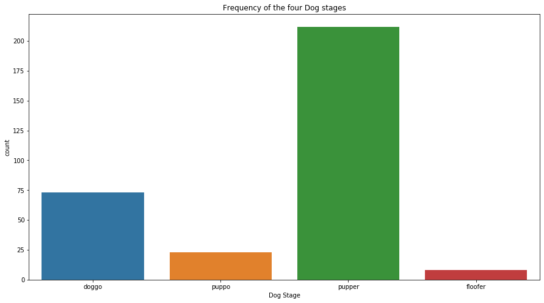

```python
# plotting the graph for the most common dog_stage that people own

plt.figure(figsize=(15,8));
sns.countplot(data=df, x='dogs_stage');
plt.title('Frequency of the four Dog stages');
plt.xlabel('Dog Stage');
plt.savefig('dogs_stage.png')
```

> Most of the dogs are not having any stage information still Pupper is the most common dog stage among the four.

### 2. What is the relation between favorite_count and retweet_count?

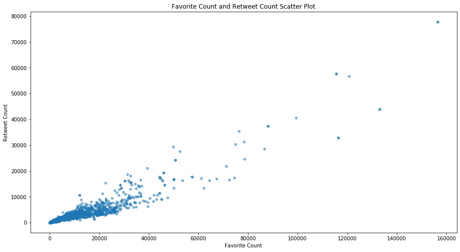

```python
#Favorite Count and Retweet Count Scatter Plot

df.plot(kind='scatter',x='favorite_count',y='retweet_count', alpha = 0.5, figsize = (15,8));
plt.xlabel("Favorite Count");
plt.ylabel('Retweet Count');
plt.title('Favorite Count and Retweet Count Scatter Plot');
plt.savefig('scatter_plot.png')
```

There is a positive correlation between favorite_count and retweet_count.

### 3. What are the 10 most frequent predicted dog breeds?

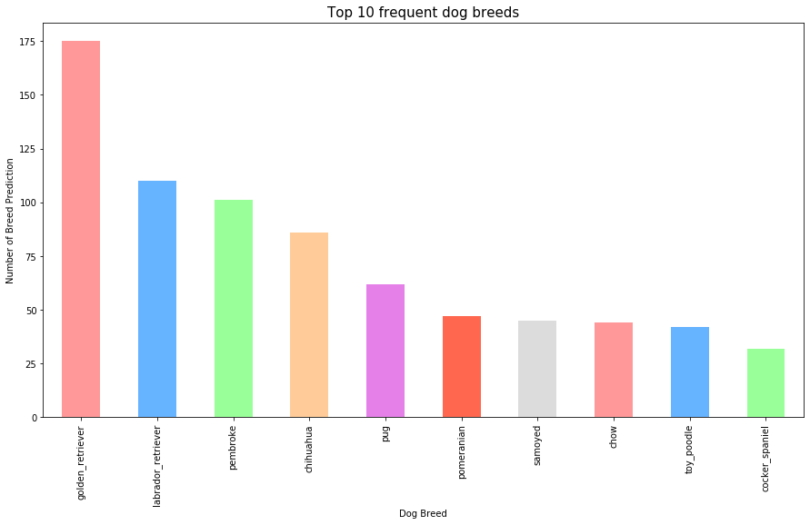

```python
# plotting the graph for the 10 most frequent predicted dog breeds

df['p1'].value_counts()[0:10].plot(kind = 'bar', figsize = (15,8), color = ('#ff9999','#66b3ff','#99ff99','#ffcc99','#E580E8','#FF684F','#DCDCDD'));
plt.ylabel('Number of Breed Prediction');
plt.title('Top 10 frequent dog breeds', size=15);
plt.xlabel('Dog Breed');
plt.savefig('dog_breed.png')
```

### 4. What is the most common numerator rating for a dog?

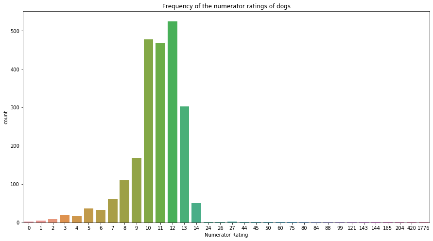

```python
# plotting the graph for the most common numerator rating for a dog

plt.figure(figsize=(15,8));
sns.countplot(data=df, x='rating_numerator');
plt.title('Frequency of the numerator ratings of dogs');
plt.xlabel('Numerator Rating');
plt.savefig('rating_numerator.png')
```

> The most common rating for a dog is 12, 10, and 11 after that comes 13.

## Sources

1. https://seaborn.pydata.org/tutorial.html
2. https://stackabuse.com/reading-and-writing-json-to-a-file-in-python
3. https://stackoverflow.com/questions/28384588/twitter-api-get-tweets-with-specific-id
4. https://en.wikipedia.org/wiki/WeRateDogs
5. https://stackoverflow.com/questions/12309269/how-do-i-write-json-data-to-a-file
6. https://pandas.pydata.org/
7. https://stackoverflow.com/questions/7370801/measure-time-elapsed-in-python?answertab=oldest#tab-top